# STATS 406, Homework 02

## Problem 2 (2 pt)

For continuous random variables $X$ and $Y$ with density $f(x, y)$, recall the **conditional expectation** of $Y$ given $X = x$ is given by:

$$E(Y \mid X = x) = \int_{-\infty}^\infty y \, f(y \mid x) \, dy = h(x)$$

Prove the *law of iterated expectation*:

$$E(E(Y \mid X)) = E(Y)$$

or equivalently,
$$E(h(X)) = E(Y)$$
Hint: Because density functions are **non-negative**, you may exchange the order of integration in $\int_{-\infty}^\infty \int_{-\infty}^\infty f(x,y) \, dx dy = \int_{-\infty}^\infty \int_{-\infty}^\infty f(x,y) \, dy dx$ (Tonelli’s theorem).

Proof: [

$$\begin{align}
E(E(Y|X))&=\int_{-\infty}^{\infty}E(Y|X)f(x)dx \\
&=\int_{-\infty}^{\infty}(\int_{-\infty}^{\infty}yf(Y|X)dy)f(x)dx \\
&=\int_{-\infty}^{\infty}y(\int_{-\infty}^{\infty}f(Y|X))f(x)dxdy \\
&=\int_{-\infty}^{\infty}y(\int_{-\infty}^{\infty}f(x,y))dxdy \\
&=\int_{-\infty}^{\infty}yf(y)dy \\
&=E(Y)
\end{align}$$

]

## Problem 3 (4 pts)

For this problem, we’ll continue to use the Spotify tracks data we met last week.

```r
load("tracks.rda")
```

You may wish to skim the chapter on visualization in [R for Data Science](https://r4ds.had.co.nz/data-visualisation.html).

### Part a (1 pt)

We can create a basic scatter plot of two variables using the following code:

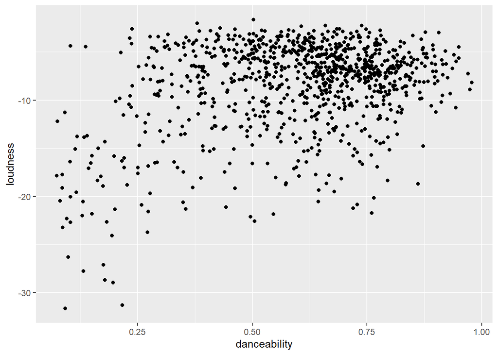

```r
ggplot(tracks, aes(x = danceability, y = loudness)) + geom_point()
```

The `x` and `y` aesthetics are not our only choice. One at a time, create new two plots using `size` and `color` connected to the `energy` column in the data set. Which of these plots do you prefer, and why?

### Part b (1 pt)

Sometimes it is more useful to replace the entire data set with a smooth line that represents the data on average (we’ll talk about how these lines are created later in the course).

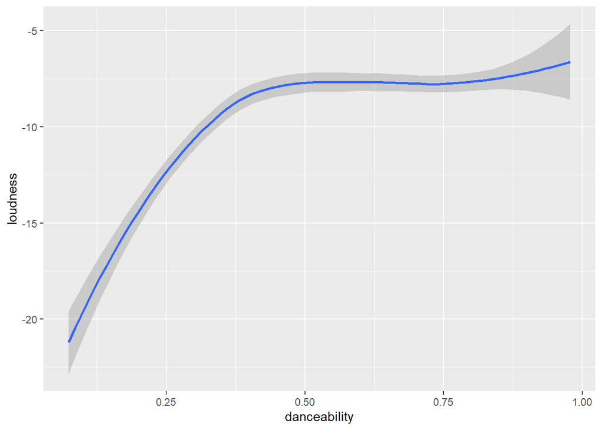

```r
ggplot(tracks, aes(x = danceability, y = loudness)) + geom_smooth()
```

Here we see an upward trend in loudness as danceability approaches 0.5, at which point it levels off.

Does this hold for all musical keys? Use the `facet_wrap` function to create “small multiples” showing the relationship between loudness and danceability with each key.

Do you notice any particular keys that differ from the overall pattern?

### Part c (2 pts)

Prepare a plot that displays interesting features from the tracks data of your choice. Give particular attention to how your plot uses coordinates, points, lines, shapes, and the visual variables of size, value, texture, color, orientation, and shape ([here’s a chart showing the variables in action](https://www.axismaps.com/guide/general/visual-variables/)). You do not need to include all types of graphical variables in your plot.

Provide a brief discussion of the visual variables you use and what aspects of the data these variables communicate. Additionally, either draw conclusions or discuss questions generated from your plot.